# Covid death II

Lin Tan

2/15/2021

## Factors related to death cases

After exploring the changes in death cases over a year during the pandemic, I wanted to know what factors were related to higher death rates in some countries but not other countries, so I explored some factors including, GDP per capita, hospital beds per thousand, medium age of the country. I looked at the scatterplot between total deaths per million by January 31, 2021 and these factors.I ran a linear model as a preliminary step to see whether these factors were related to total deaths, and the median age of people in the country was related to total deaths significantly.

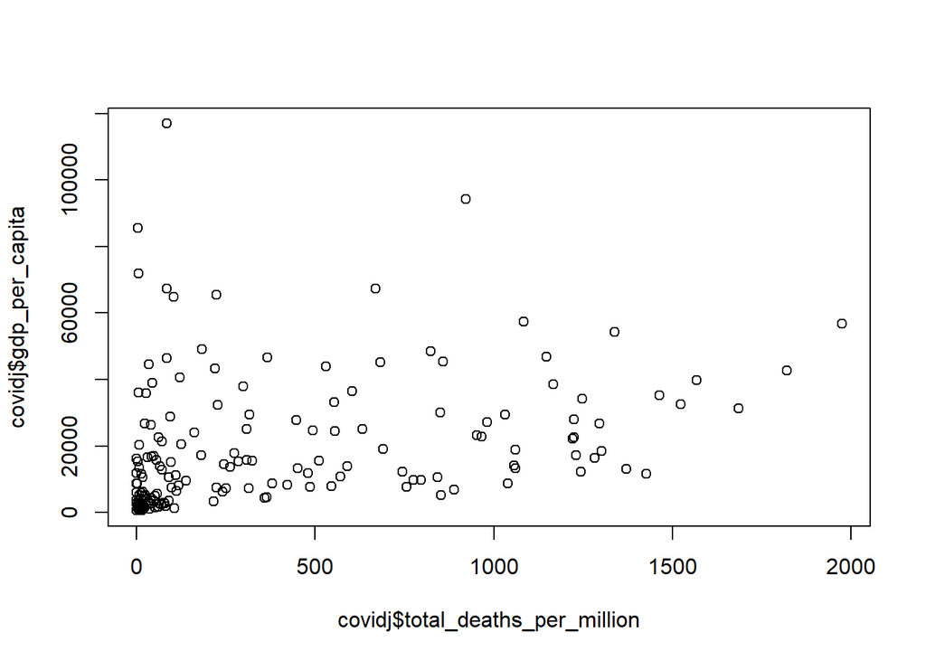

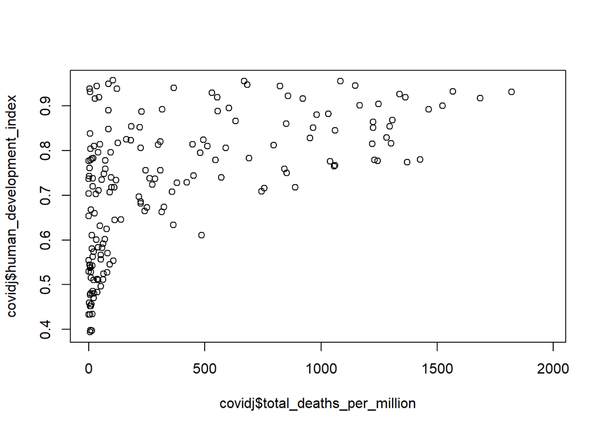

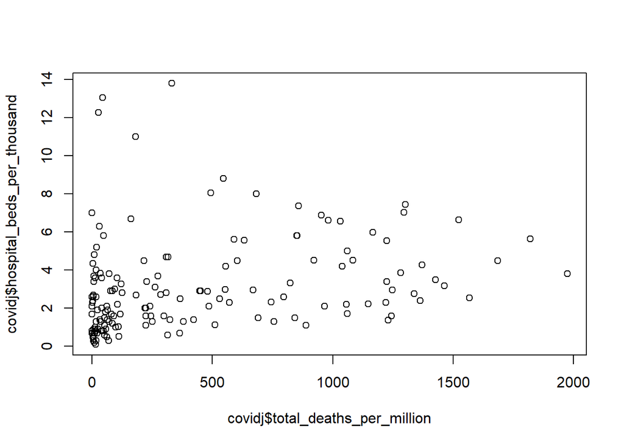

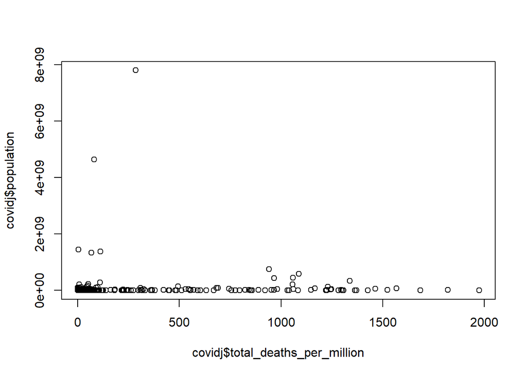

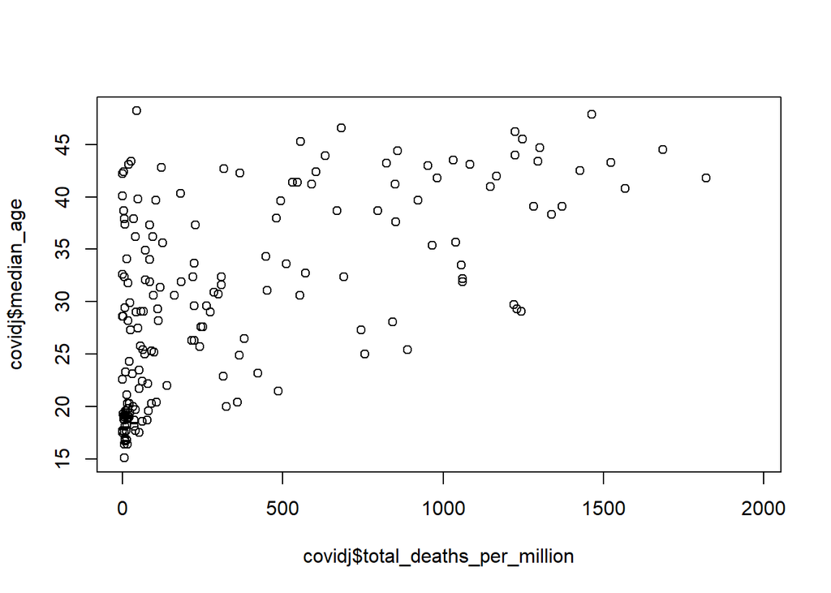

```
##
## Call:
## lm(formula = total_deaths_per_million ~ median_age + gdp_per_capita +
##     hospital_beds_per_thousand, data = covidj)
##
## Residuals:
##     Min      1Q  Median      3Q     Max
## -808.26 -262.05  -32.37  189.32 1154.42
##
## Coefficients:
##                              Estimate Std. Error t value Pr(>|t|)
## (Intercept)                -7.487e+02  1.369e+02  -5.471 1.84e-07 ***
## median_age                  4.210e+01  5.824e+00   7.230 2.30e-11 ***
## gdp_per_capita             -3.909e-03  1.981e-03  -1.973   0.0503 .
## hospital_beds_per_thousand -3.173e+01  1.816e+01  -1.747   0.0827 .
## ---
## Signif. codes:  0 '***' 0.001 '**' 0.01 '*' 0.05 '.' 0.1 ' ' 1
##
## Residual standard error: 382.4 on 150 degrees of freedom
##   (54 observations deleted due to missingness)
## Multiple R-squared:  0.3573, Adjusted R-squared:  0.3445
## F-statistic:  27.8 on 3 and 150 DF,  p-value: 2.357e-14
```

## TOP 10 Countires

Lastly, I looked at the top 10 countries that had the lowest total deaths per million and the top 10 countries that had the highest total deaths per million by January 31, 2021. It is very interesting to find that none of the top 10 countries that had the lowest deaths per million were European and North American countries, and all the top 10 countries that had the highest deaths per million were European and North American countries.

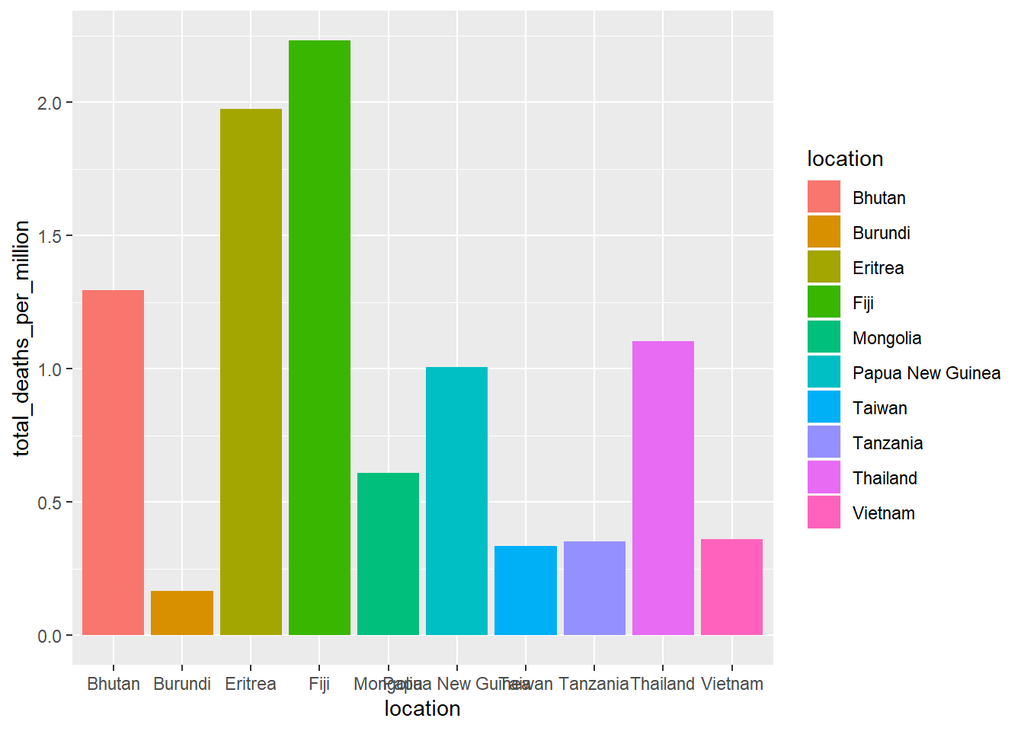

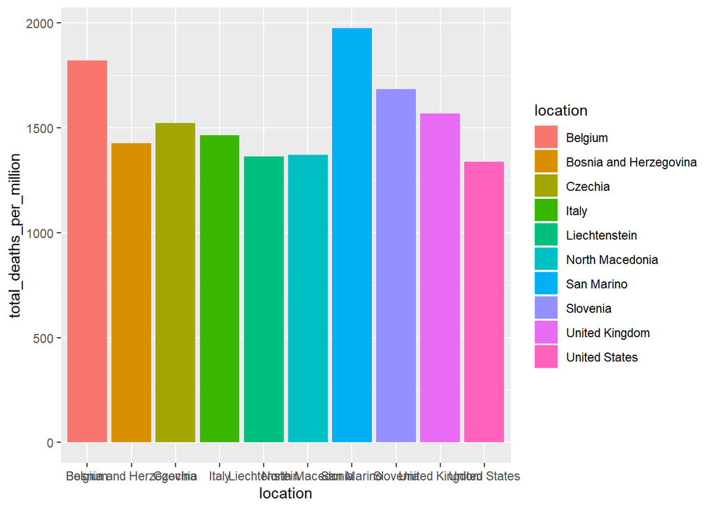